# Inteligencia Artificial Generativa (AI Gen)

Modelos Generativos de Señales, Imágenes y Multimodalidad

Autor: Paulo Veiga, Claudio Righetti, Marco Sorondo (Universidad Austral)  
Última modificación: 2026-10-28

01Qué es una convolución 02Segmentación: qué es y para qué sirve 03De FCN a U-Net 04SAM: segmentar lo que le señalás 05Generación condicionada por texto 06Stable Diffusion por dentro 07TilTedTinder v2 y notebook

01

Qué es una convolución

Qué es una convolución

## Una red neuronal clásica solo acepta entradas de largo fijo

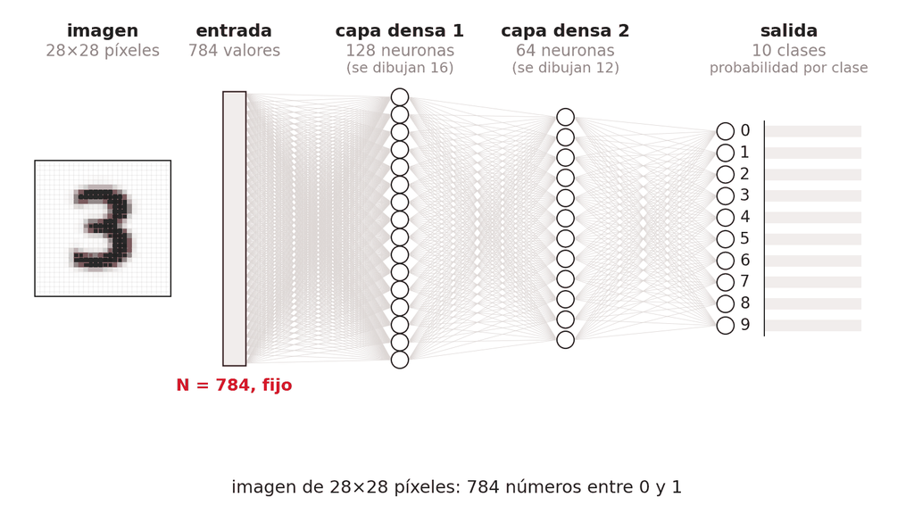

Qué es una convolución

## Una red neuronal clásica solo acepta entradas de largo fijo

Una red densa (MLP) recibe un vector con una cantidad fija de números. Esa cantidad queda fija al definir la primera capa, porque cada entrada tiene sus propios pesos. Tareas que una red así resuelve bien:

### Precio de una casa

Los atributos de la propiedad (metros cuadrados, barrio, ambientes) entran como un vector y sale un número. Es el caso del TP de MLP.

### Dígitos manuscritos (MNIST)

La imagen de 28×28 se aplana en 784 números y salen 10 probabilidades, una por dígito.

### Riesgo crediticio

Los datos de una solicitud entran normalizados y sale la probabilidad de que el cliente no pague.

Qué es una convolución

## Cómo se entrena una red densa

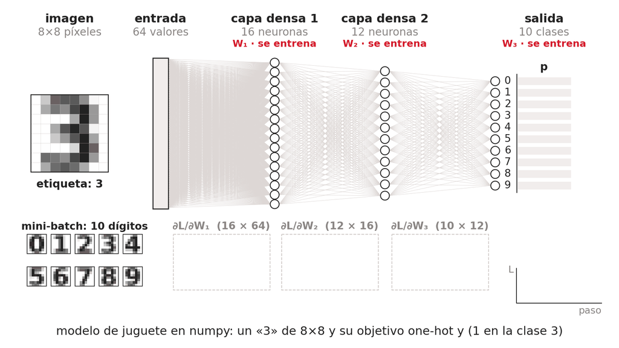

Qué es una convolución

## El detector de voz: cada audio dura distinto

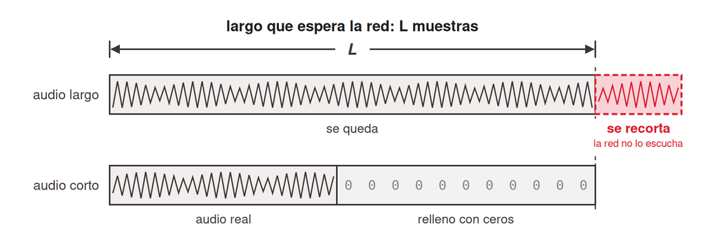

Qué es una convolución

## El detector de voz: cada audio dura distinto

Querés una red que escuche una grabación y diga si alguien está hablando. Un audio de 5 s tiene más muestras que uno de 2 s, y la red densa espera siempre la misma cantidad. Con un MLP tenés que elegir un largo L y forzar todos los audios a ese largo:

### Recortar los audios largos

Si la voz estaba en el tramo que cortaste, esa parte nunca entra a la red.

### Rellenar con ceros los cortos

La red recibe silencio artificial y tiene que aprender a ignorarlo.

Qué es una convolución

## El sesgo inductivo equivocado

Aun con el largo resuelto, una capa densa trata al audio como una lista de números sin orden.

### Sin vecindad

Cada muestra se conecta con cada neurona con pesos independientes. Si mezclás el orden de las entradas (la misma mezcla en todos los ejemplos) y reentrenás, la red aprende igual de bien. En su arquitectura la muestra t no está al lado de la t+1.

### Sin invariancia a traslación

Un "hola" al principio del audio y el mismo "hola" al final pasan por pesos distintos. La red tiene que aprender el patrón una vez por cada posición.

### Demasiados parámetros

Cada entrada suma una fila de pesos. Una imagen RGB de 224×224 son 150.528 números, y una primera capa densa de 256 neuronas ya tiene unos 38,5 millones de pesos.

Qué es una convolución

## El problema aparece en cualquier señal, y en las imágenes

La limitación no depende de la tarea. Con audio y señales:

TareaEjemploQué sale

Clasificación¿hay voz en esta grabación?una etiqueta

Regresiónestimar la frecuencia cardíaca desde un ECGun número

Filtradosacarle el ruido a una grabaciónuna señal del mismo largo

Upscalingllevar un audio a una frecuencia de muestreo más altauna señal con más muestras

Generaciónsintetizar vozuna señal nueva

**Imágenes**: Las imágenes tienen el mismo problema en dos dimensiones: alto y ancho cambian de una foto a otra, y cada píxel trae sus canales (3 en RGB). Un MLP obliga a llevarlas todas a un tamaño y aplanarlas.

Qué es una convolución

## La solución: un kernel que se desliza

Un kernel de 9 pesos iguales a 1/9 (un promedio móvil) filtra un audio ruidoso.

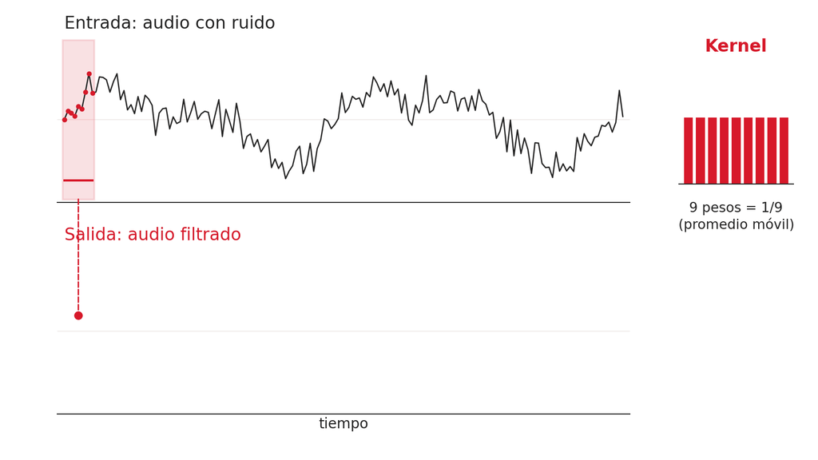

Qué es una convolución

## La solución: un kernel que se desliza

Un **kernel** es un vector chico de pesos que recorre la señal. En cada posición multiplica sus pesos por el tramo que tiene debajo, suma y escribe un número en la salida. Después avanza una muestra y repite. En la animación, un kernel de 9 pesos iguales a 1/9 (un promedio móvil) filtra un audio ruidoso:

### Arriba

La ventana del kernel avanza sobre el audio con ruido.

### Abajo

Cada punto de la salida aparece cuando el kernel pasa por esa posición.

### Al final

La salida conserva la forma de la onda con menos ruido.

**Pesos compartidos**: Usa los mismos pesos en todas las posiciones. Por eso detecta un patrón esté donde esté, y la cantidad de pesos no depende del largo del audio.

Qué es una convolución

## Mismo mecanismo, otra tarea: detectar voz

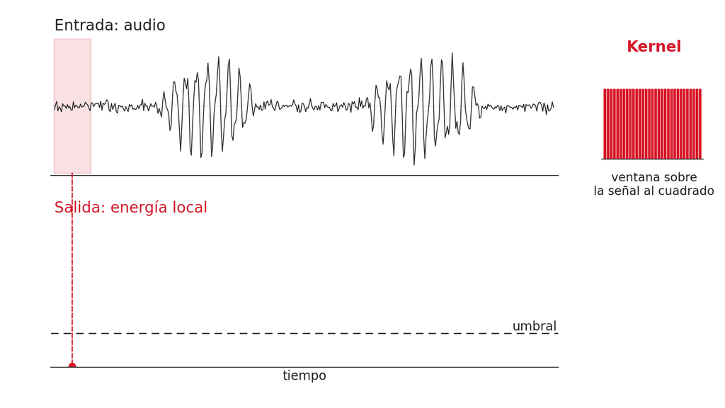

Qué es una convolución

## Mismo mecanismo, otra tarea: detectar voz

Con otro kernel, una ventana larga sobre la señal al cuadrado, la misma operación mide la energía local del audio: cuánta señal hay alrededor de cada instante. Donde la energía pasa un umbral, el detector marca voz.

### Tramos con voz

La salida sube; en los silencios baja.

### Umbral

La línea horizontal; lo que queda por encima se marca como voz.

**Pesos aprendidos**: En una red convolucional nadie elige los pesos del kernel a mano. Los aprende el entrenamiento, igual que los de una capa densa.

Qué es una convolución

## El largo variable deja de ser un problema

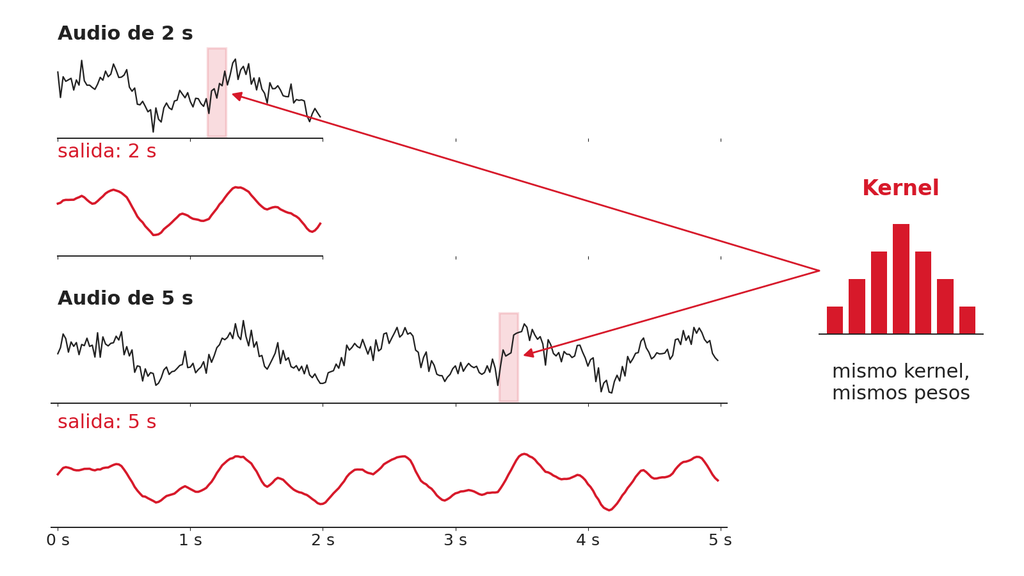

Qué es una convolución

## El largo variable deja de ser un problema

### Cualquier largo

El kernel funciona con cualquier duración de audio: se desliza hasta que la señal se termina. Sobre 2 s produce una salida corta, sobre 5 s una más larga, con los mismos pesos.

### Pooling global

Para clasificar la grabación entera, la red resume esa salida en un vector de largo fijo, por ejemplo con un pooling global que toma el promedio o el máximo. Recién ahí entra una capa densa.

Qué es una convolución

## Dos soluciones al largo variable

### Convolución

Un kernel chico recorre la entrada con los mismos pesos en cada posición.

- Lo que detecta en un lugar lo detecta en cualquier otro (invariancia a traslación).
- Cada salida combina solo valores cercanos. Ese sesgo inductivo fuerte, la localidad, le permite aprender con menos datos.
- Para relacionar puntos lejanos hay que apilar capas.

### Atención (transformer)

Cada posición se combina con todas las demás desde la primera capa, con pesos que calcula la atención.

- La atención sola no codifica el orden; el orden lo ponen los positional embeddings, que el transformer trae de serie.
- Su sesgo inductivo es débil, por eso requiere más datos y a cambio captura dependencias lejanas.
- El costo crece con el cuadrado del largo.

Elegir una arquitectura es elegir un sesgo inductivo.

Qué es una convolución

## Convolución en imágenes

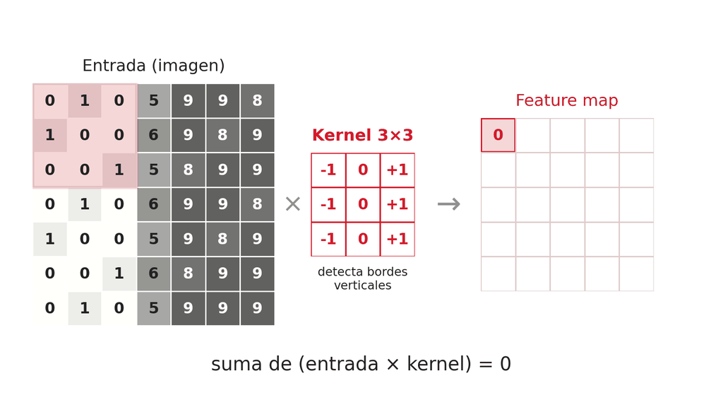

Qué es una convolución

## Convolución en imágenes

En una imagen el kernel es una grilla chica, por ejemplo de 3×3, que recorre la imagen a lo alto y a lo ancho. En cada posición multiplica sus 9 pesos por los 9 píxeles que cubre y suma.

### Una celda por posición

Cada lugar donde se apoya el kernel produce una celda del feature map.

### Tamaño

Sobre una grilla de 7×7, un kernel de 3×3 sin relleno cabe en 5 posiciones por fila y por columna, y la salida es de 5×5.

### Bordes

Los valores grandes aparecen donde el kernel cruza un borde.

**Parámetros**: Sobre una imagen RGB el kernel abarca los 3 canales a la vez: 3×3×3 = 27 pesos. Una capa `nn.Conv2d(3, 32, 3)` con 32 kernels tiene 896 parámetros, contra los 38,5 millones de la capa densa.

Qué es una convolución

## Distintos kernels, distintos rasgos

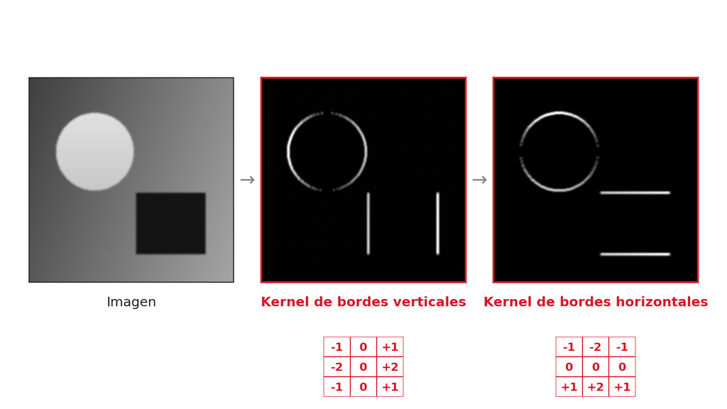

Qué es una convolución

## Distintos kernels, distintos rasgos

1

Cada kernel detecta un rasgo. En la figura, uno resalta los bordes verticales y otro los horizontales de la misma imagen.

2

Una CNN apila capas convolucionales y aprende sus kernels. Las primeras capas detectan bordes, las siguientes texturas, después partes y al final objetos.

3

Esa pila es el encoder de FCN y de la U-Net, que aparecen en la sección de segmentación.

Qué es una convolución

## Cómo se aprende un kernel

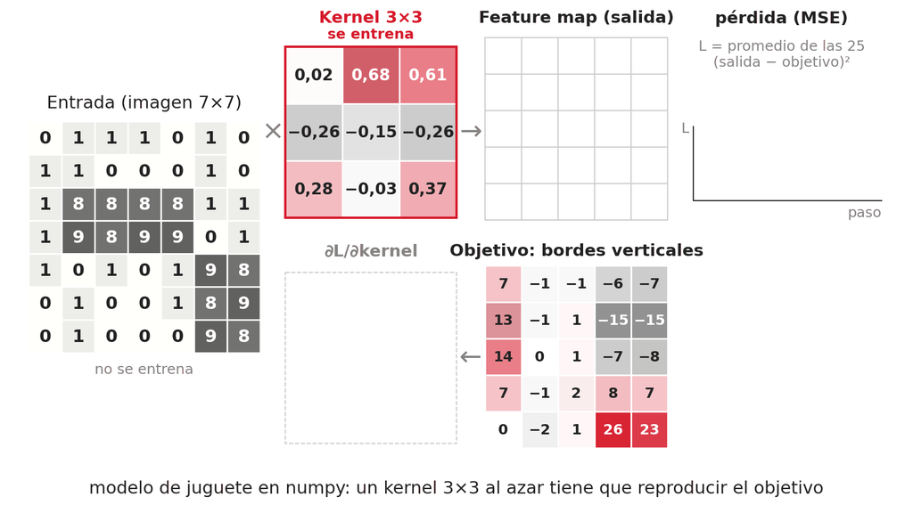

Qué es una convolución

## Embeddings más allá del texto

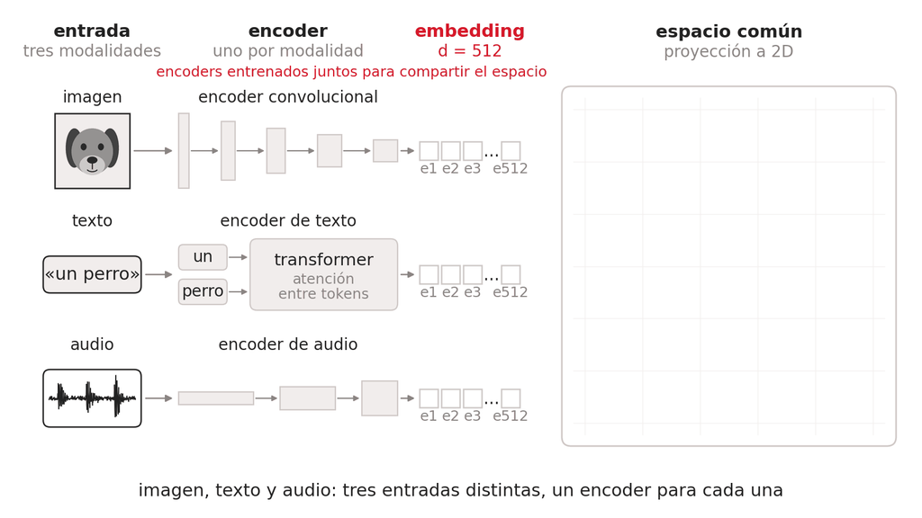

Qué es una convolución

## Embeddings más allá del texto

### Un vector por entrada

El encoder de una CNN termina en un vector de largo fijo que resume el contenido de la imagen. Un encoder de texto hace lo mismo con una oración, y uno de audio con una grabación.

### Embedding

Una representación densa aprendida donde la geometría del espacio codifica el significado: vectores cercanos, contenidos parecidos. Sirve para cualquier modalidad, con o sin transformers.

### Vuelve dos veces en esta clase

CLIP pone imágenes y textos en el mismo espacio, y el VAE de Stable Diffusion comprime la imagen en un latente donde trabaja la difusión.

01Qué es una convolución 02Segmentación: qué es y para qué sirve 03De FCN a U-Net 04SAM: segmentar lo que le señalás 05Generación condicionada por texto 06Stable Diffusion por dentro 07TilTedTinder v2 y notebook

02

Segmentación: qué es y para qué sirve

Segmentación: qué es y para qué sirve

## ¿Qué es segmentar?

En visión por computadora, hay tres preguntas distintas que podemos hacerle a una imagen — y segmentar es la más fina de todas.

TareaPreguntaSalida

Clasificación¿Qué hay en esta imagen?Una etiqueta (ej: "perro")

Detección¿Dónde está y qué es?Cajas con etiquetas

Segmentación¿Qué representa cada píxel?Una etiqueta por píxel — una "máscara"

**Frase clave**: Segmentar es darle un significado **pixel por pixel** a la imagen.

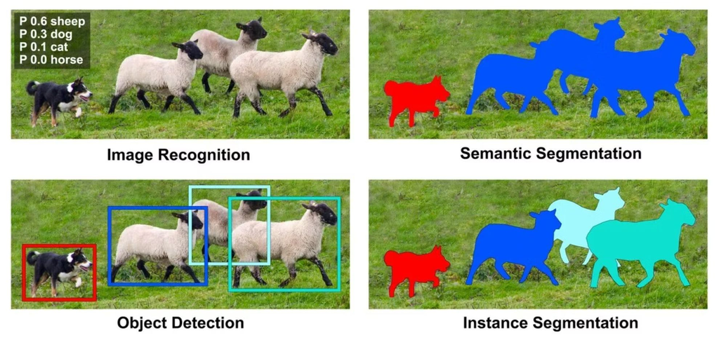

Segmentación: qué es y para qué sirve

## Tipos de segmentación

Tres niveles de granularidad, según qué tan finamente queramos diferenciar lo que vemos:

### Semántica

Etiqueta cada píxel con su clase, sin distinguir individuos. Todos los píxeles de "auto" reciben la misma etiqueta, aunque haya cinco autos.

### De instancias

Distingue cada objeto individual. "Auto 1", "auto 2", "auto 3"... aunque sean de la misma clase.

### Panóptica

Combina ambas — clasifica cada píxel y distingue instancias. Es la versión más completa.

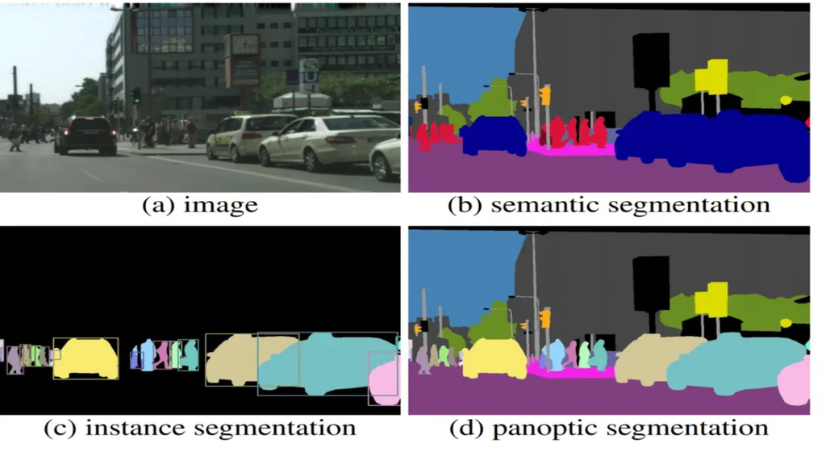

Segmentación: qué es y para qué sirve

## Dónde se usa

### Autos autónomos

Separar carretera, peatones, semáforos y otros vehículos.

### Imagen satelital

Medir cobertura forestal, urbanización y cuerpos de agua.

### Videoconferencia y edición de fotos

Separar a la persona del fondo en tiempo real; el "Seleccionar sujeto" de Photoshop.

### Neuroimagen y oncología

Delinear tumores y lesiones; medir volumen tumoral para planificar radioterapia.

### Cardiología

Delimitar ventrículos para calcular la fracción de eyección.

### Patología, oftalmología y dermatología

Contar núcleos y mitosis, segmentar vasos retinianos, delimitar lesiones.

En medicina la máscara es lo que se mide, se documenta y se compara entre estudios.

Segmentación: qué es y para qué sirve

## Cómo se ve una salida

- **Visualización típica**: Imagen original (MRI cardíaca) → **máscara binaria** (blanco = estructura, negro = fondo) → overlay sobre la imagen → mapa de probabilidad por píxel.
- **Internamente**: La máscara es una **matriz** del mismo tamaño que la imagen, donde cada celda dice a qué clase pertenece ese píxel. Para 2 clases es 0/1; para N clases es 0..N-1.

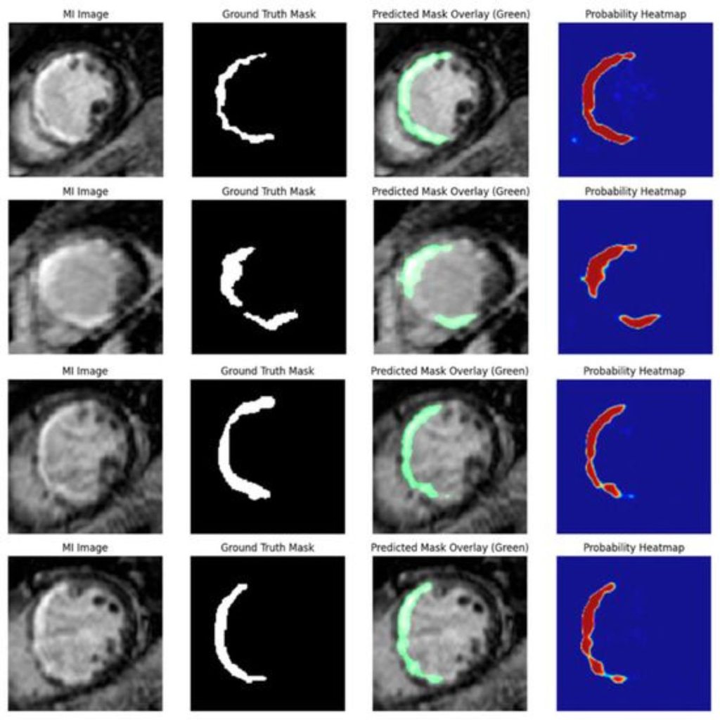

01Qué es una convolución 02Segmentación: qué es y para qué sirve 03De FCN a U-Net 04SAM: segmentar lo que le señalás 05Generación condicionada por texto 06Stable Diffusion por dentro 07TilTedTinder v2 y notebook

03

De FCN a U-Net

De FCN a U-Net

## La intuición: clasificar cada píxel

Si segmentar es asignar una etiqueta a cada píxel, la idea más directa es tratar cada píxel como un mini-problema de clasificación.

### Lo que ya sabemos: CNN clásica

Clasifica la imagen entera.

- Comprime la imagen con convoluciones + pooling.
- Al final, una capa densa entrega una clase.

### La idea de FCN

Fully Convolutional Network (Long et al., 2015).

- Saca la capa densa final.
- La reemplaza por capas convolucionales que producen una salida espacial del mismo tamaño que la entrada.

**Una sola frase**: "Convertí un clasificador de imágenes en un **clasificador de píxeles**".

De FCN a U-Net

## FCN por dentro

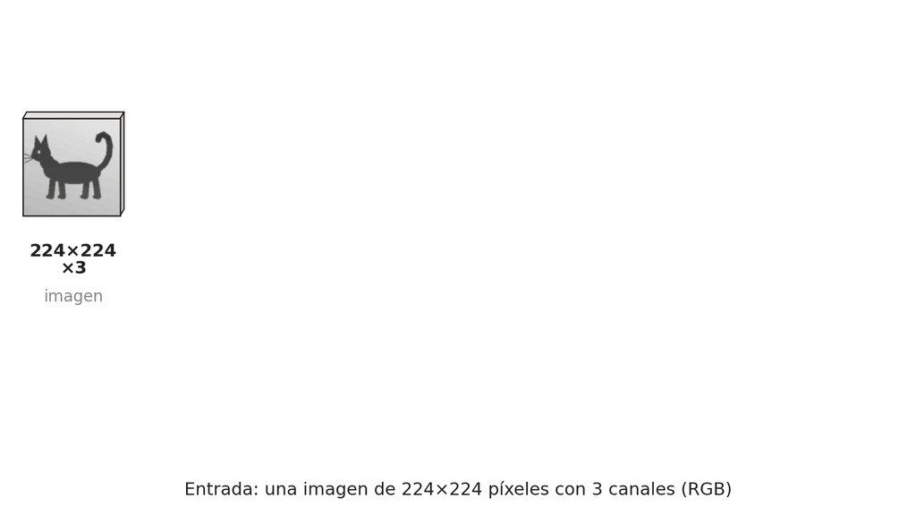

De FCN a U-Net

## FCN por dentro

1

#### Encoder convolucional

La imagen se comprime capa a capa; cada capa detecta patrones más abstractos (bordes, texturas, estructuras, objetos).

2

#### Convoluciones 1×1

En lugar de la capa densa: se mantienen las dimensiones espaciales. Sale un mapa chico con probabilidades por clase.

3

#### Upsampling

Convoluciones traspuestas estiran ese mapa hasta el tamaño original.

**Resultado**: Una máscara con una etiqueta por píxel. Fue el primer modelo de segmentación end-to-end con deep learning.

De FCN a U-Net

## El problema de FCN

Durante el encoder, la red comprime mucho: una imagen de **512×512** puede terminar como un mapa de **16×16**. Cuando hacemos upsampling para volver al tamaño original, la información espacial fina ya se perdió.

### Síntoma

Los contornos quedan **borrosos** o redondeados. El borde exacto de un tumor o el contorno de un núcleo celular desaparecen.

### En medicina

Si estás midiendo el volumen de un tumor para decidir radioterapia, un borde 2 píxeles más adentro o más afuera cambia el cálculo y puede cambiar la decisión clínica.

**La pregunta**: ¿Cómo recuperamos los detalles finos que el encoder descartó?

De FCN a U-Net

## U-Net: la U y sus atajos

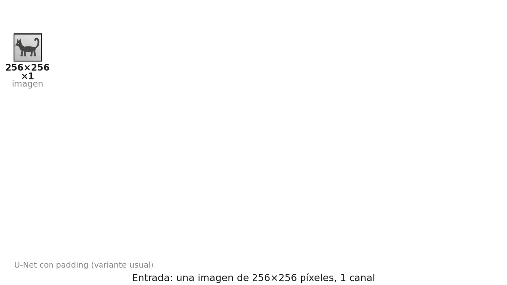

De FCN a U-Net

## U-Net: la U y sus atajos

Ronneberger, Fischer y Brox (Universidad de Friburgo, 2015) la diseñaron para segmentar **células en microscopía electrónica**, con muy pocas imágenes etiquetadas.

### Encoder

Convoluciones + max pooling. En cada nivel la resolución se reduce a la mitad y los canales se duplican. Las features codifican cada vez mejor "qué hay" y pierden "dónde está".

### Decoder

Convoluciones traspuestas. La resolución se duplica en cada nivel y "dónde" se reconstruye.

### Skip connections

La salida de cada nivel del encoder se concatena con la entrada del decoder en el mismo nivel. El decoder recibe qué es (desde abajo) y dónde está exactamente (desde el atajo).

De FCN a U-Net

## Cómo se entrena un modelo de segmentación

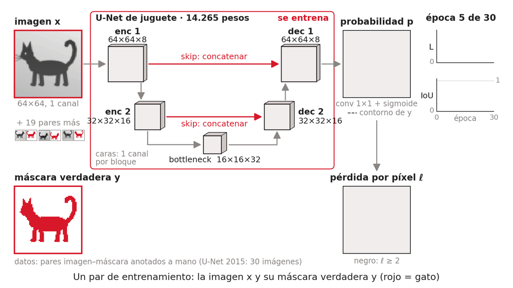

De FCN a U-Net

## Por qué funciona tan bien en medicina

### Funciona con pocos datos

Las skip connections actúan como un regularizador estructural. U-Net puede entrenarse con cientos de imágenes, no miles, y aún así generalizar bien. Crítico cuando etiquetar requiere un radiólogo.

### Contornos precisos

Los detalles finos sobreviven el viaje por la U. En medicina, el borde es el dato.

### Es modular y adaptable

La misma arquitectura funciona para MRI de cerebro, células de patología, retina, ecografía cardíaca... cambia el dataset, no la red.

01Qué es una convolución 02Segmentación: qué es y para qué sirve 03De FCN a U-Net 04SAM: segmentar lo que le señalás 05Generación condicionada por texto 06Stable Diffusion por dentro 07TilTedTinder v2 y notebook

04

SAM: segmentar lo que le señalás

SAM: segmentar lo que le señalás

## SAM: segmentación promptable

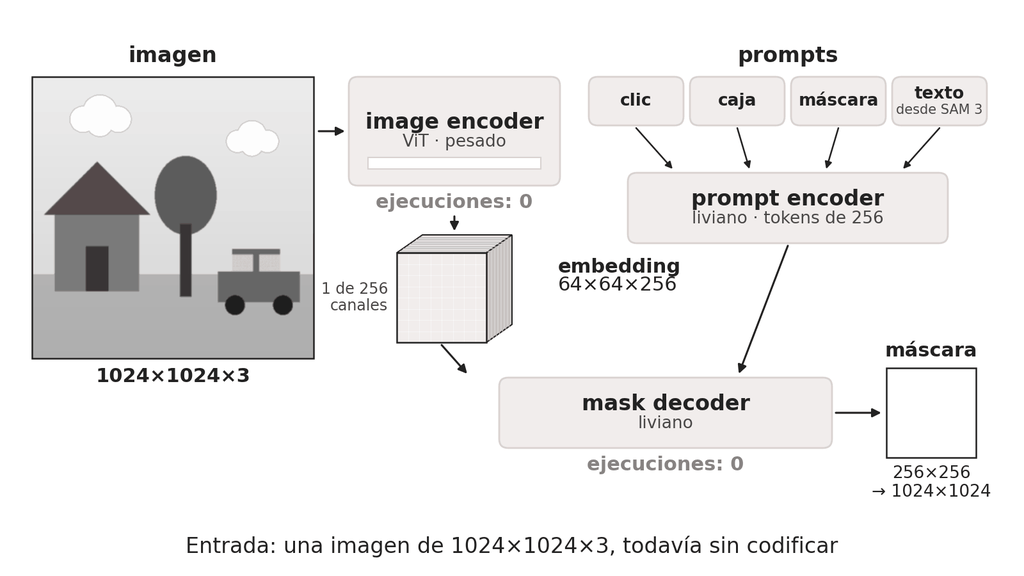

SAM: segmentar lo que le señalás

## SAM: segmentación promptable

SAM (Segment Anything Model, Meta, 2023) es el opuesto de la U-Net: un **foundation model** masivo que segmenta cualquier cosa en cualquier imagen, sin reentrenamiento.

Recibe una imagen + una pista (un click, una caja, una máscara aproximada o, desde SAM 3, texto) y devuelve la máscara del objeto que querés.

**El truco:** La imagen se codifica **una sola vez**. Después podés probar decenas de prompts sobre esa misma imagen; solo se reejecuta el decoder liviano.

**SA-1B:** 1.000 millones de máscaras sobre 11 millones de imágenes, armado con un data engine donde el propio SAM ayudaba a anotar.

SAM: segmentar lo que le señalás

## Cómo se entrena SAM

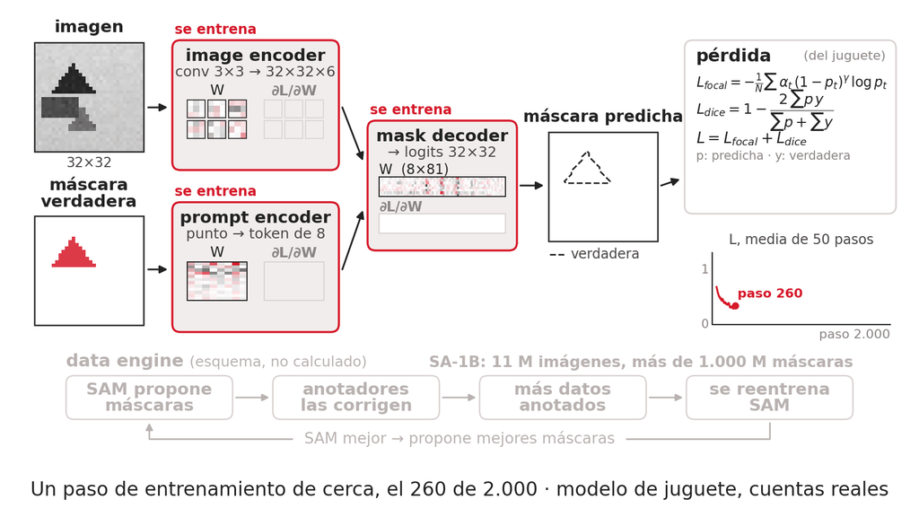

SAM: segmentar lo que le señalás

## SAM 2: memoria para video

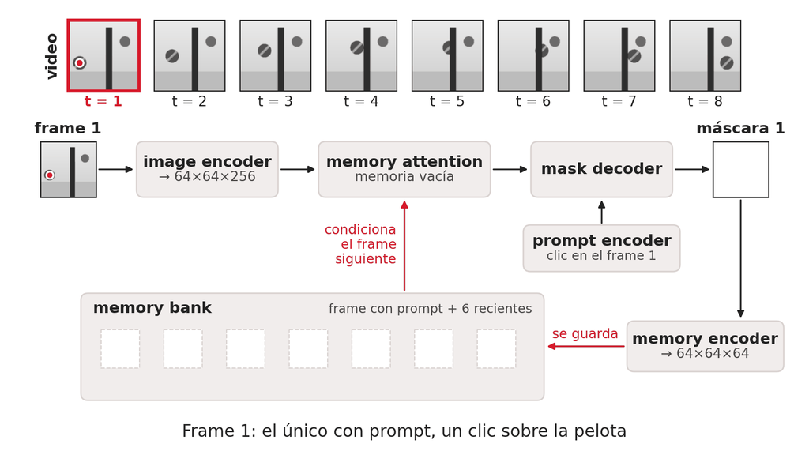

SAM: segmentar lo que le señalás

## SAM 2: memoria para video

SAM 2 (julio 2024) extiende SAM al video con un módulo de memoria que mantiene la segmentación coherente entre frames.

### Guardar

Después de cada frame.

- Cada máscara que sale pasa por un memory encoder.
- El resultado se guarda en un memory bank.

### Recordar

En el frame siguiente.

- La memory attention combina las features del image encoder con lo que quedó guardado.
- Así la máscara sigue al mismo objeto aunque se mueva.

SAM: segmentar lo que le señalás

## Cómo se entrena SAM 2

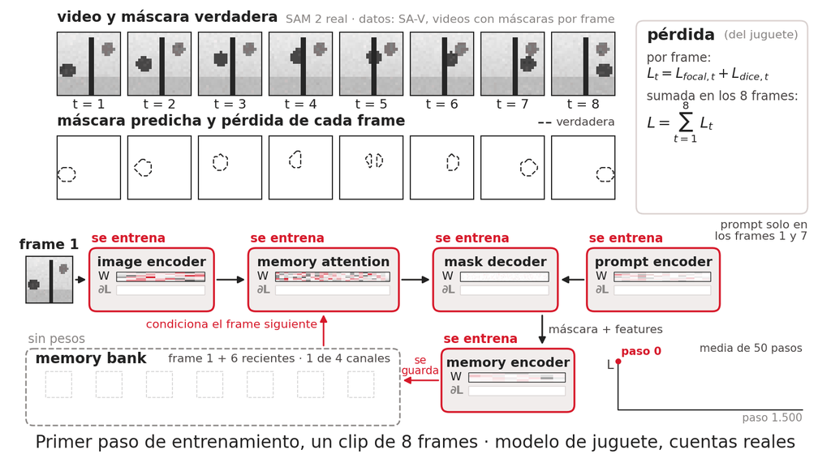

SAM: segmentar lo que le señalás

## SAM 3 y 3.1: texto y muchos objetos

#### SAM 1 · Abril 2023

Foundation model para imágenes. Prompts visuales: puntos, cajas, máscaras.

#### SAM 2 · Julio 2024

Extiende SAM al video — módulo de memoria que mantiene la segmentación coherente entre frames.

#### SAM 3 · Noviembre 2025

Suma prompts de texto y vocabulario abierto. Permite pedir "todos los hepatocitos" en lenguaje natural.

#### SAM 3.1 · Marzo 2026

Object Multiplex: tracking conjunto multi-objeto con memoria compartida, sin sacrificar precisión.

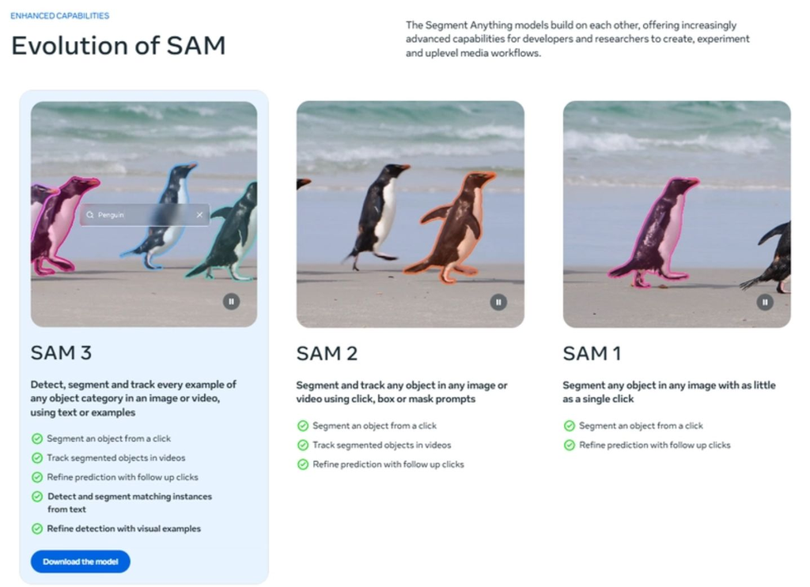

SAM: segmentar lo que le señalás

## U-Net es modular: adelanto

U-Net no es solo para segmentación. Encoder que comprime + decoder que reconstruye + skip connections sirve para cualquier tarea donde la entrada y la salida tengan el **mismo tamaño espacial** y haya que preservar detalles finos.

### Restauración de imágenes

Denoising, deblurring, super-resolución.

### Image-to-image translation

MRI → CT, día → noche.

### El corazón de **Stable Diffusion**

Dentro de un rato la vamos a usar para quitar ruido paso a paso de una imagen.

01Qué es una convolución 02Segmentación: qué es y para qué sirve 03De FCN a U-Net 04SAM: segmentar lo que le señalás 05Generación condicionada por texto 06Stable Diffusion por dentro 07TilTedTinder v2 y notebook

05

Generación condicionada por texto

Generación condicionada por texto

## TilTedTinder: el nuevo desafío

En la clase pasada, una **Vanilla GAN** le llenó la base de datos a TilTedTinder, la app de citas de Slanted Land, con rostros inclinados nuevos a partir de solo 4 fotos reales. Un año después la app tiene miles de usuarios, y cada uno describe lo que le atrae:

### "Me atraen las personas inclinadas, altas, con anteojos y pelo rizado."

### "Prefiero caras inclinadas, jóvenes, con sonrisa y barba corta."

### "Me gustan las inclinadas, mayores, con expresión seria y rasgos angulosos."

Pasamos de "generá una persona inclinada cualquiera" a "generá una persona inclinada con **estos atributos descritos en texto libre**".

Generación condicionada por texto

## Por qué la GAN no alcanza

### Vanilla GAN

Aprende una única cosa, "producir algo que parezca un rostro inclinado". No tiene ningún canal para recibir descripciones.

### Conditional GAN

Condiciona por etiquetas predefinidas ("alto", "con anteojos"). Las preferencias reales son frases con matices que no encajan en categorías cerradas.

### StyleGAN

Da control de estilo, pero no semántico. No podés pedirle "expresión melancólica al atardecer".

**La nueva tarea, text-to-image**: Escribís un prompt en lenguaje natural y el modelo genera una imagen que coincide. Permite combinar conceptos que el modelo nunca vio juntos ("un astronauta montando un caballo").

Generación condicionada por texto

## Text-to-image en cinco años

#### 2021

**DALL·E 1** (OpenAI): primera demo viral.

#### 2022

DALL·E 2, Imagen (Google), Midjourney: salto enorme en realismo.

#### Agosto 2022

**Stable Diffusion 1.4**: primer modelo open source serio, con pesos publicados, que corre en una GPU de consumo.

#### 2023

DALL·E 3, SDXL, Midjourney v5/v6: siguen mejor prompts complejos.

#### 2024

FLUX, Stable Diffusion 3, Sora: texto a imagen se vuelve commodity; texto a video empieza a funcionar.

Hoy vemos las tripas de Stable Diffusion porque abrió el ecosistema y porque su arquitectura ya la conocemos en parte.

Generación condicionada por texto

## CLIP: el puente texto ↔ imagen

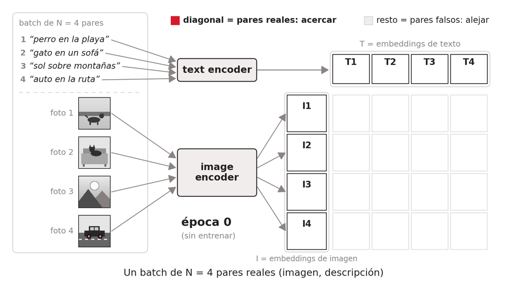

Generación condicionada por texto

## CLIP: el puente texto ↔ imagen

Una red no procesa palabras: el texto se tokeniza, cada token pasa a un vector y un encoder Transformer produce un embedding de la oración completa.

### Dos encoders, un espacio

CLIP (OpenAI, 2021).

- Entrena en paralelo un encoder de imagen y otro de texto.
- Sus salidas viven en el mismo espacio vectorial.

### Entrenamiento contrastivo

400 millones de pares (imagen, descripción) de internet.

- Los pares reales quedan cerca.
- Los mal apareados quedan lejos.

Ese embedding de texto es la entrada con la que la U-Net de Stable Diffusion se condiciona.

Generación condicionada por texto

## Cómo se entrena CLIP

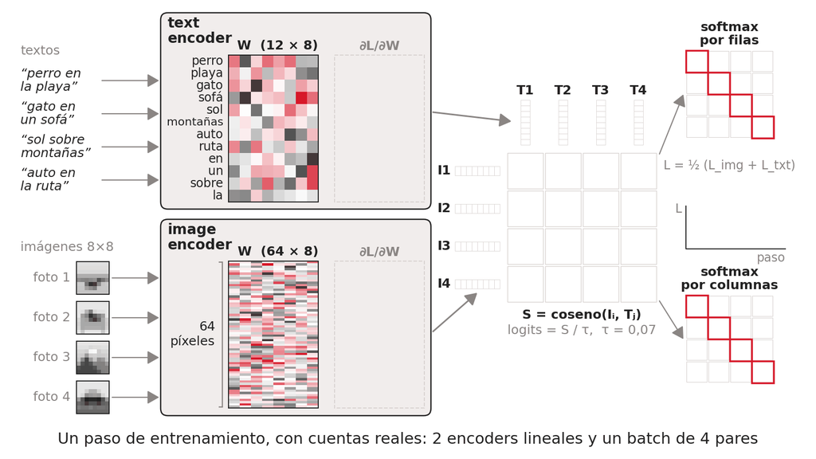

Generación condicionada por texto

## La idea de condición

Generación incondicionalGeneración condicionada

Ruido aleatorio → red → imagen. La red genera lo que aprendió, sin guía.Ruido aleatorio + condición → red → imagen que respeta la condición.

La condición puede ser una etiqueta de clase (cGAN), una imagen de referencia (Pix2Pix) o un **embedding de texto** (Stable Diffusion).

La condición dirige **cada paso** de la generación. Si dice "perro en la playa", la red empuja el ruido en cada iteración hacia algo que se parezca a eso.

01Qué es una convolución 02Segmentación: qué es y para qué sirve 03De FCN a U-Net 04SAM: segmentar lo que le señalás 05Generación condicionada por texto 06Stable Diffusion por dentro 07TilTedTinder v2 y notebook

06

Stable Diffusion por dentro

Stable Diffusion por dentro

## La idea de difusión: agregar y quitar ruido

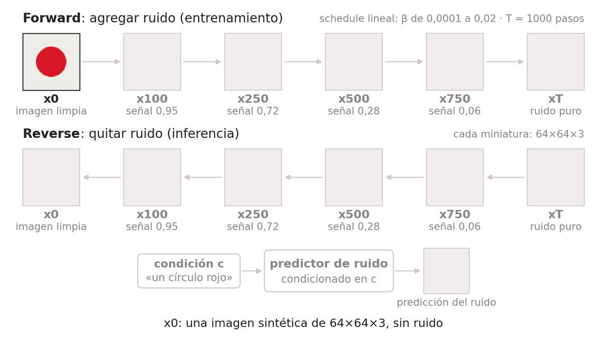

Stable Diffusion por dentro

## La idea de difusión: agregar y quitar ruido

Difusión viene de la física: una gota de tinta en un vaso de agua se dispersa hasta volverse uniforme.

### Reverse (inferencia)

La red hace el camino inverso. Arranca de ruido puro y quita ruido paso a paso, guiada por la condición c.

La red aprende una sola cosa: dado un latente ruidoso y un timestep, **predecir qué ruido fue agregado**. Con esa predicción, el ruido se puede restar.

Stable Diffusion por dentro

## Del ruido a la imagen

El proceso inverso sobre una imagen real: de ruido puro (x_T) a la muestra limpia (x_0).

[figure not shown]

Stable Diffusion por dentro

## Latent diffusion: difundir en un espacio comprimido

Rombach et al. (CompVis, 2021) propusieron difundir en un **espacio latente** comprimido.

786.432valores en una imagen de 512×512 RGB: la difusión directa sobre píxeles (DALL·E 2, Imagen) es cara, y cada uno de los 50 a 1000 pasos de denoising los procesa todos

16.384valores en el latente: una imagen de 512×512×3 se comprime a 64×64×4

48×menos valores por paso

**Resultado**: Stable Diffusion corre en una GPU de consumo (8-16 GB) en pocos segundos.

Stable Diffusion por dentro

## Las tres piezas de Stable Diffusion

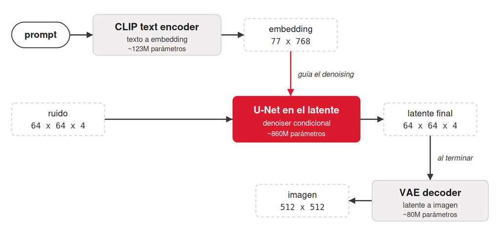

Stable Diffusion por dentro

## Las tres piezas de Stable Diffusion

ComponenteQué haceTamaño aprox.

VAE (Variational Autoencoder)Comprime imagen ↔ latente~80M params

UNETDenoiser condicional en espacio latente~860M params

CLIP Text EncoderPrompt de texto → embedding~123M params

Stable Diffusion por dentro

## Componente 1: el VAE

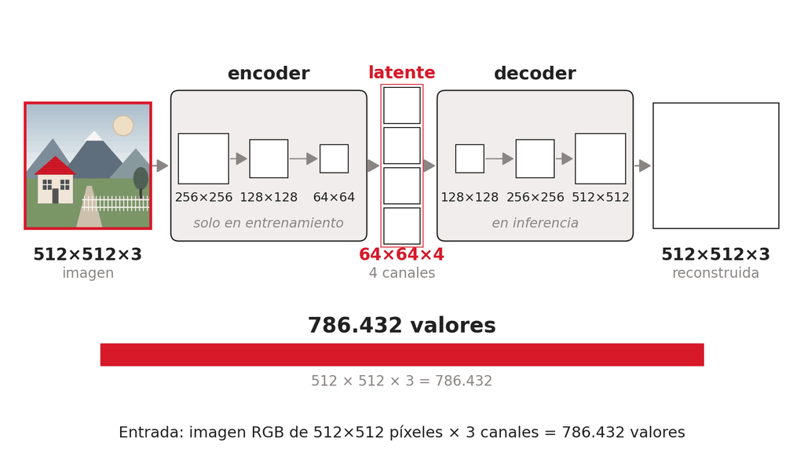

Stable Diffusion por dentro

## Componente 1: el VAE

### Encoder

Toma la imagen 512×512×3 y la mapea a un latente 64×64×4. Compresión ~48×.

### Decoder

Toma un latente 64×64×4 y reconstruye una imagen 512×512×3.

En el entrenamiento de SD se usa el encoder, para llevar las imágenes del dataset al latente. En inferencia **solo se usa el decoder**.

Stable Diffusion por dentro

## Cómo se entrena el VAE

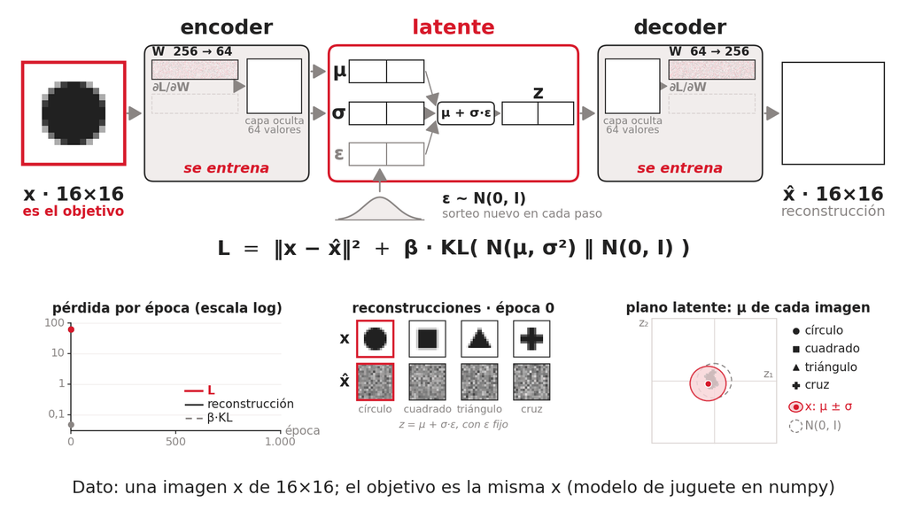

Stable Diffusion por dentro

## Componente 2: la U-Net, de vuelta

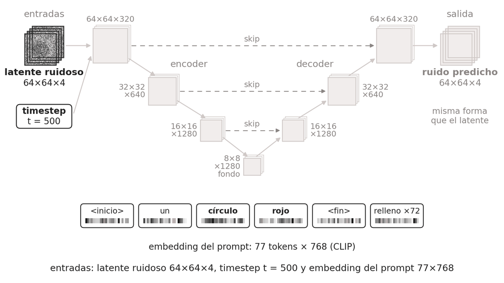

Stable Diffusion por dentro

## Componente 2: la U-Net, de vuelta

La misma estructura que vimos en segmentación: encoder + decoder en U + skip connections.

### Cambia la tarea

U-Net de segmentación: entra una imagen, sale una máscara. U-Net de SD: entran **latente ruidoso, timestep y embedding del prompt**; sale la **predicción del ruido** presente en el latente.

### Cross-attention

En cada nivel de la U, bajando y subiendo, un bloque calcula pesos entre las features de la imagen y cada token del embedding de CLIP, y suma la información de los tokens ponderada por esos pesos.

Stable Diffusion por dentro

## Componente 3: el CLIP Text Encoder

SD 1.x usa el text encoder de **CLIP ViT-L/14** (~123M parámetros), congelado: el equipo de SD no lo reentrena, lo toma prestado de OpenAI.

### Entrada

El prompt (ej: "un astronauta montando un caballo"), tokenizado a **77 tokens** (con padding si la frase es corta, truncado si es larga).

### Salida

Una matriz de embeddings de **77 × 768**, que se enchufa a la U-Net en cada bloque de cross-attention.

~123Mparámetros, congelado

77tokens por prompt

77 × 768embedding que entra a la U-Net

Stable Diffusion por dentro

## Pipeline completo de inferencia

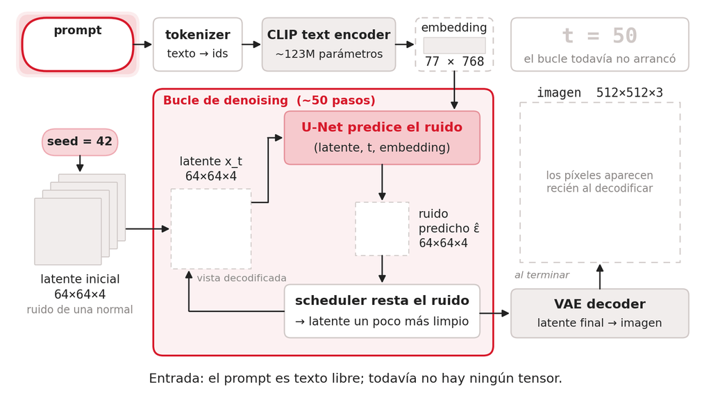

Stable Diffusion por dentro

## Pipeline completo de inferencia

1

#### Prompt

Tokenizer → CLIP Text Encoder → embedding de texto (77 × 768).

2

#### Latente inicial

Un tensor aleatorio de 64×64×4 desde una normal, controlado por la seed. Es el bloque de mármol que vamos a tallar.

3

#### Bucle de denoising

(~50 pasos): la U-Net recibe (latente, t, embedding) y predice el ruido; el scheduler lo resta.

4

#### Decodificar

Latente final 64×64×4 → VAE Decoder → imagen 512×512×3.

Stable Diffusion por dentro

## Cómo se entrena Stable Diffusion

[figure not shown]

Stable Diffusion por dentro

## Los hiperparámetros que importan

### num_inference_steps

Cuántos pasos de denoising. Default 50. Por debajo de 20 la calidad se degrada; por encima de 100 las mejoras son marginales.

### guidance_scale

(classifier-free guidance): qué tan estricto seguir el prompt. Default 7.5. Bajo (1-3) más diverso y menos fiel; medio (7-9) el punto justo; alto (15+) muy fiel pero saturado.

### seed

Controla el ruido inicial. Misma seed + mismo prompt = misma imagen.

### height y width

Múltiplos de 8, porque el VAE comprime 8×. Default 512×512.

**Para iterar**: Fijá la seed y el guidance, y mové el prompt. Así aislás el efecto de cada cambio de texto.

Stable Diffusion por dentro

## Limitaciones de Stable Diffusion

### Manos y anatomía

Dedos de más o fundidos, ojos asimétricos, articulaciones raras.

### Texto dentro de la imagen

Carteles y etiquetas salen como caracteres pseudo-aleatorios. Mejoró en SD 3 y FLUX.

### Conteo y composición

"Tres manzanas" puede salir con dos o cinco; "un perro a la izquierda y un gato a la derecha" es frágil.

### Sesgos del dataset

LAION-5B refleja sesgos demográficos, culturales y estéticos de internet. Importa en aplicaciones médicas y sociales.

### Costo de inferencia

Sigue siendo caro para deployment masivo en tiempo real.

01Qué es una convolución 02Segmentación: qué es y para qué sirve 03De FCN a U-Net 04SAM: segmentar lo que le señalás 05Generación condicionada por texto 06Stable Diffusion por dentro 07TilTedTinder v2 y notebook

07

TilTedTinder v2 y notebook

TilTedTinder v2 y notebook

## De preferencias a prompts

Ya tenemos las piezas: el usuario escribe un prompt, CLIP lo convierte en un embedding, la U-Net talla la imagen paso a paso y el VAE la decodifica.

### Usuario A

"Me atraen las personas inclinadas, altas, con anteojos y pelo rizado."

### Usuario B

"Prefiero caras inclinadas, jóvenes, con sonrisa y barba corta."

### Usuario C

"Inclinadas, mayores, expresión seria, rasgos angulosos."

TilTedTinder v2 y notebook

## De preferencias a prompts

Un buen prompt combina **sujeto + atributos + estilo + luz**.

Mismo prompt + **misma seed** = mismo perfil estable cuando el usuario vuelve a abrir la app.

```
A: prompt = "a tilted portrait of a tall person with round glasses and curly hair, soft natural lighting, photorealistic, 4k"
B: prompt = "a tilted portrait of a young person with a warm smile and short beard, soft daylight, candid photo, shallow depth of field"
C: prompt = "a tilted portrait of an older person with a serious expression and angular features, dramatic shadows, black and white photography"
```

TilTedTinder v2 y notebook

## Lo que el equipo va a encontrar

### Slanted Land no está en los datos de SD

LAION-5B no tiene caras inclinadas, así que las primeras generaciones saldrán rectas. Solución: fine-tuning con las 4 fotos reales, con DreamBooth o LoRA.

### Sesgo demográfico

Hay grupos sobrerrepresentados y otros casi ausentes. El equipo tiene que auditar las generaciones.

### Control de detalle limitado

No podés pedir "exactamente esa nariz". Para detalles finos, iterar o usar ControlNet e Inpainting.

### Costo

50 perfiles por usuario en tiempo real es caro. Caché, generación batched offline o modelos rápidos (SDXL Turbo, FLUX Schnell).

### Ética

¿Se le avisa al usuario que el perfil es sintético? ¿Hay riesgo de manipulación emocional?

TilTedTinder v2 y notebook

## Pasamos al notebook

**Stack**: Google Colab con GPU (Tesla T4, 16 GB) · Hugging Face Diffusers · Stable Diffusion v1.4 (CompVis) en `float16`.

1

#### Pipeline alto nivel

`StableDiffusionPipeline.from_pretrained(...)` y generar imágenes en pocas líneas.

2

#### Hiperparámetros

Mover `num_inference_steps`, `guidance_scale` y `seed`, y ver qué cambia.

3

#### Grids

Varias imágenes de un mismo prompt para ver la variabilidad.

4

#### Dimensiones

Imágenes rectangulares (512×768).

5

#### Pipeline manual

Desarmar el pipeline en VAE + U-Net + CLIP y reconstruirlo a mano.

Conclusiones

## Key takeaways

### Una convolución

desliza un kernel chico de pesos compartidos sobre la señal: acepta cualquier largo y detecta un patrón esté donde esté. Su encoder resume la entrada en un embedding.

### Segmentar

es etiquetar cada píxel; en medicina, la máscara es el dato que se mide.

### U-Net

recupera los bordes que FCN pierde gracias a las skip connections, y funciona con pocas imágenes etiquetadas.

### SAM

segmenta cualquier objeto a partir de una pista: click, caja, máscara o texto.

### Stable Diffusion

combina tres piezas: CLIP convierte el prompt en un embedding, la U-Net quita ruido en el latente y el VAE lo vuelve imagen.

### La misma U-Net

aparece en las dos mitades de la clase: segmenta células y talla imágenes desde ruido.

Girá el teléfono para ver las diapositivas